# Spatial summation of individual cones in human color vision

[Brian P. Schmidt](https://bps10.github.io), Alexandra E. Boehm, William S. Tuten, Austin Roorda

2019-01-09

# Introduction

A central goal of vision science is to understand how signals from photoreceptors are transformed into sight and the limitations each stage of processing imposes on perception. Photoreceptors provide an organism with real-time information about the environment. However, the signals conveyed by individual neurons are noisy and ambiguous. One strategy for reducing uncertainty is to pool signals across multiple detectors. Under low light conditions, for example, the visual system combines signals from many hundreds of rod and cone photoreceptors in order to boost sensitivity . One drawback of signal pooling is a loss in spatial resolution: both acuity and contrast sensitivity are reduced under low-light levels . We studied the influence of spatial pooling on the color appearance of cone-targeted spots.

# Results

## Load data and import libraries.

First load in data and set some parameters that will be used during plotting later.

```r
# setwd("~/R/Schmidt-Boehm-Tuten-Roorda_2019")
library(tidyverse)
library(ggthemes)
library(gridExtra)
library(corrplot)
library(car)
# set the colors that will be used in plots below.
red <- "#e84040"
green <-"#40c631"
blue <- "#4042e8"
yellow <- "#e8df40"
gray <- "#595959"
# make sure a figures directory exists
dir.create('figures', showWarnings=FALSE)
```

```r
trial_data <- read_csv('filtered_data.csv')
head(trial_data)
```

| yb | delivery_error | distance_btwn_cones_arcmin | distance_to_Scone_1 | distance_to_Scone_2 | distance_to_Scone_3 | distance_to_Scone_4 | distance_to_Scone_5 | isPair | lConeNeighbors | masterID1 | masterID2 | gr | session | subject | trial | type1 | type2 | x1 | x2 | y1 | y2 | typeID | typeIDstr | saturation |
| --- | --- | --- | --- | --- | --- | --- | --- | --- | --- | --- | --- | --- | --- | --- | --- | --- | --- | --- | --- | --- | --- | --- | --- | --- |
| 0.0 | 0.2140770 | 1.277753 | 1.0879676 | 1.151751 | 1.317078 | 2.030381 | 3.984664 | TRUE | 0.4000000 | 68 | 16 | 0.0 | 37 | 10001R | 1 | 2 | 2 | 70 | 74 | 92 | 100 | 4 | M+M-pair | 0.0 |
| 0.0 | 0.1933480 | 0.000000 | 1.0879676 | 1.151751 | 1.597191 | 2.030381 | 4.063275 | FALSE | 0.3333333 | 68 | 68 | -0.2 | 37 | 10001R | 2 | 2 | 2 | 70 | 70 | 92 | 92 | 2 | M-cone | 0.2 |
| -0.2 | 0.2426758 | 0.000000 | 1.0879676 | 1.151751 | 1.597191 | 2.030381 | 4.063275 | FALSE | 0.3333333 | 68 | 68 | -0.2 | 37 | 10001R | 3 | 2 | 2 | 70 | 70 | 92 | 92 | 2 | M-cone | 0.4 |
| -0.2 | 0.2150870 | 0.000000 | 1.0879676 | 1.151751 | 1.597191 | 2.030381 | 4.063275 | FALSE | 0.3333333 | 68 | 68 | 0.2 | 37 | 10001R | 4 | 2 | 2 | 70 | 70 | 92 | 92 | 2 | M-cone | 0.4 |
| 0.0 | 0.2014013 | 0.000000 | 0.8571429 | 1.672100 | 2.060315 | 2.123724 | 3.431546 | FALSE | 0.5000000 | 41 | 41 | 0.0 | 37 | 10001R | 5 | 3 | 3 | 77 | 77 | 94 | 94 | 3 | L-cone | 0.0 |
| 0.0 | 0.1720731 | 0.000000 | 1.3170778 | 1.767045 | 2.222336 | 2.626397 | 3.984664 | FALSE | 0.6666667 | 16 | 16 | 0.0 | 37 | 10001R | 6 | 2 | 2 | 74 | 74 | 100 | 100 | 2 | M-cone | 0.0 |

## Example session

The results of one session are plotted in Fig~B. In this example, Cone 1 was an M-cone and had a bias towards green. Cone 2 was an L-cone and elicited predominantly white reports. Cone 3, also an L-cone, was rated reddish-yellow (orange) with medium saturation. The motivation for this study was to understand the algorithm the visual system uses when combining information across cone pairs. In the example, when Cone 1 was targeted together with either Cone 2 or Cone 3, the average report was desaturated. In comparison, when Cone 2 and 3 were targeted they elicited a medium saturated orange report. Below, we analyze the results from all sessions and subjects.

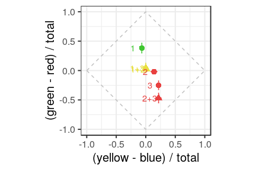

```r
example <- trial_data %>%
  filter(., subject == '20076R', session== 4) %>%
  group_by(., masterID1, masterID2, isPair) %>%
  summarise(., yb_mean=signif(mean(yb), 3),
            yb_sem=signif(sd(yb) / sqrt(length(yb)), 3),
            gr_mean=signif(mean(gr), 3),
            gr_sem=signif(sd(gr) / sqrt(length(gr)), 3), N=length(gr),
            typeIDstr=typeIDstr[1])
boundary <- data.frame(x=c(-1, 0, 1, 0, -1), y=c(0, 1, 0, -1, 0))
(examplePlot <- ggplot(data=example,
                       aes(x=yb_mean,
                           y=gr_mean,
                           color=interaction(typeIDstr, isPair),
                           shape=isPair)) +
    geom_point(size=3) +
    geom_errorbar(aes(x=yb_mean, ymin=gr_mean - gr_sem, ymax=gr_mean + gr_sem)) +
    geom_errorbarh(aes(y=gr_mean, xmin=yb_mean - yb_sem, xmax=yb_mean + yb_sem, height=0.01)) +
    coord_equal(xlim=c(-1, 1), ylim=c(-1, 1)) +
    xlab('(yellow - blue) / total') +
    ylab('(green - red) / total') +
    scale_color_manual(
      values = c(red, green, red, yellow),
      name="spectral type") +
    geom_text(label=c('1', '1+2', '1+3', '2', '2+3', '3'),
              nudge_x=-0.15) +
    geom_path(data = boundary, aes(x=x, y=y), colour='gray', linetype=2, inherit.aes = F) +
    theme_bw(base_size = 15) +
    theme(legend.position="none")
  )
```

```r
ggsave("figures/example_session.pdf")
```

## Variability in sensations from cones with the same sensitivity

Each point in these plots represents the mean response measured from a single cone or a pair. This plot illustrates the variability in responses across cones/pairs and between subjects. There are a few features to note. Firstly, within a single subject, there was considerable variability between cones and pairs with the same spectral sensitivity. Similar variability in sensations from single cones has been reported previously (Hofer et al. 2005; Sabesan et al. 2016; Schmidt et al. 2018). This is the first report of variability in sensations elicited from pairs of cones. Secondly, there were individual differences in color responses: S20075 used blue more frequently than the two other subjects and S10001 did not report yellow on any trials. However, the general patterns are similar. Most of the variance was found along the green-red dimension; there were few points that fell in the blueish-red or greenish-yellow quadrants. In the two subjects with classified mosaics, we additionally found L-cone targeted trials tended produce a reddish bias, while M-cones were biased towards green. These patterns were similar to previous reports from single-cone (Sabesan et al. 2016; Schmidt et al. 2018) and large-field studies (DeValois et al. 1997).

To better appreciate the influence of cone type and number of cones targeted on color reports, data was pooled across subjects and grouped according to the type of cone or pair probed. The mean and standard error for each group is shown in the right most plot below. When an individual or pair of M-cones was targeted the average $gr$ response was greater than zero indicating a bias towards green. In comparison, the average L-cone(s) elicited biases towards red and yellow. Together these cone type specific differences in color reports were consistent with a predictive relationship between cone type and color report, as previously reported (Sabesan et al. 2016; Schmidt et al. 2018). Two cones with the same photopigment tended to elicit slightly more saturated reports than single cone trials. On the other hand, one L- and one M-cone targeted together tended to produce desaturated reports.

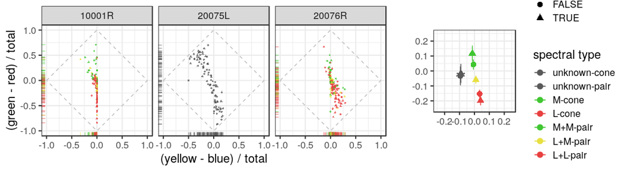

```r
(p <- grid.arrange(ind, avg, widths=2.5:1))
```

```r
ggsave("figures/UAD_combined.pdf", p)
```

## Mosaic parameters do not predict responses

The plot above demonstrates that color reports varied even between cones with the same photopigment (Schmidt et al. 2018). Some L-cones, for instance, elicited highly saturated red sensations, while a majority produce white or desaturated pink reports. We next asked whether the variability in sensations between cones with the same sensitivity could be explained by low level features of the mosaic. Specifically, can we predict whether an L-cone will produce a saturated red or a desaturated pink based on the surrounding cone types or the delivery error? And in the case of cone pairs, did the distance between the two cones influence color appearance? To answer these question, we grouped responses according to the number of cones targeted (one or two), the session in which trial occurred and the specific cone(s) that was targeted. The mean and count was then computed for each cone(s). Only those cones pairs which had at least four good trials were analyzed.

```r
minTrials <- 4
singleConesSummary <- trial_data %>%
  select(., -typeIDstr) %>%
  filter(., isPair==FALSE) %>%
  group_by(., subject, session, masterID1) %>%
  summarise_all(., c("mean", "length")) %>%
  filter(., yb_length >= minTrials) %>%
  select(., -contains("_length")) %>%
  rename_(.dots=setNames(names(.), gsub("_mean", "", names(.))))
twoConesSummary <- trial_data %>%
  select(., -typeIDstr) %>%
  filter(., isPair==TRUE) %>%
  group_by(., subject, session, masterID1, masterID2) %>%
  summarise_all(., c("mean", "length")) %>%
  filter(., yb_length >= minTrials) %>%
  select(., -contains("_length")) %>%
  rename_(.dots=setNames(names(.), gsub("_mean", "", names(.))))
```

Below is a matrix of correlation plots for the single cone condition.

```
                    yb          gr          saturation  lConeNeighbors distance_to_Scone_1 distance_to_Scone_2
yb                  "0.000e+00" "2.820e-26" "1.138e-03" "2.000e-01"    "5.135e-01"         "5.398e-01"
gr                  "2.820e-26" "0.000e+00" "1.101e-01" "2.578e-01"    "9.136e-01"         "9.673e-01"
saturation          "1.138e-03" "1.101e-01" "0.000e+00" "1.255e-01"    "2.386e-01"         "9.307e-01"
lConeNeighbors      "2.000e-01" "2.578e-01" "1.255e-01" "0.000e+00"    "1.122e-04"         "1.244e-03"
distance_to_Scone_1 "5.135e-01" "9.136e-01" "2.386e-01" "1.122e-04"    "0.000e+00"         "4.281e-18"
distance_to_Scone_2 "5.398e-01" "9.673e-01" "9.307e-01" "1.244e-03"    "4.281e-18"         "0.000e+00"
```

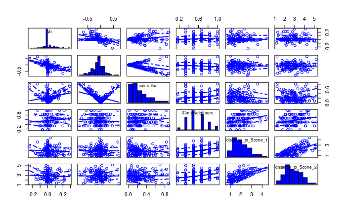

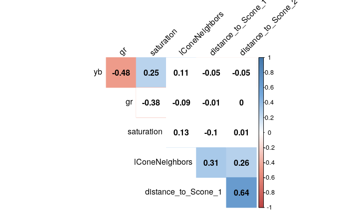

```r
ptest <- function(mat, ...) {
  # stolen from: http://www.sthda.com/english/wiki/visualize-correlation-matrix-using-correlogram
    mat <- as.matrix(mat)
    n <- ncol(mat)
    p.mat<- matrix(NA, n, n)
    diag(p.mat) <- 0
    for (i in 1:(n - 1)) {
        for (j in (i + 1):n) {
            tmp <- cor.test(mat[, i], mat[, j], ...)
            p.mat[i, j] <- p.mat[j, i] <- tmp$p.value
        }
    }
  colnames(p.mat) <- rownames(p.mat) <- colnames(mat)
  p.mat
}
corr_analysis <- function (data, predictors) {
  # scatterplotMatrix with car package
  scatterplotMatrix(data[ , predictors],
                    diagonal=list(method ="histogram"),
                    ellipse=FALSE)

  M<-cor(data[ , predictors], use="complete.obs")
  head(round(M,2))
  cor.mtest <- ptest
  # matrix of the p-value of the correlation
  p.mat <- cor.mtest(data[ , predictors])
  print(format(p.mat, digits=4))
col <- colorRampPalette(c("#BB4444", "#EE9988", "#FFFFFF", "#77AADD", "#4477AA"))
corrplot(M, method="color", col=col(200),
         type="upper",
         #order="hclust",
         addCoef.col = "black", # Add coefficient of correlation
         tl.col="black", tl.srt=45, #Text label color and rotation
         # Combine with significance
         p.mat = p.mat, sig.level = 0.01, insig = "blank",
         # hide correlation coefficient on the principal diagonal
         diag=FALSE
         )
}
predictors = c("yb", "gr", "saturation", "lConeNeighbors",
               "distance_to_Scone_1", "distance_to_Scone_2")
corr_analysis(singleConesSummary, predictors)
```

Two cone condition:

```
                           yb          gr          saturation  lConeNeighbors distance_btwn_cones_arcmin
yb                         "0.000e+00" "1.963e-31" "9.787e-04" "3.704e-01"    "3.019e-01"
gr                         "1.963e-31" "0.000e+00" "1.655e-01" "2.613e-02"    "8.605e-01"
saturation                 "9.787e-04" "1.655e-01" "0.000e+00" "9.544e-01"    "7.302e-03"
lConeNeighbors             "3.704e-01" "2.613e-02" "9.544e-01" "0.000e+00"    "9.895e-01"
distance_btwn_cones_arcmin "3.019e-01" "8.605e-01" "7.302e-03" "9.895e-01"    "0.000e+00"
distance_to_Scone_1        "7.549e-02" "6.574e-01" "7.046e-02" "2.741e-05"    "5.186e-01"
distance_to_Scone_2        "2.468e-01" "4.834e-01" "6.474e-01" "3.262e-04"    "1.137e-01"
                           distance_to_Scone_1 distance_to_Scone_2
yb                         "7.549e-02"         "2.468e-01"
gr                         "6.574e-01"         "4.834e-01"
saturation                 "7.046e-02"         "6.474e-01"
lConeNeighbors             "2.741e-05"         "3.262e-04"
distance_btwn_cones_arcmin "5.186e-01"         "1.137e-01"
distance_to_Scone_1        "0.000e+00"         "7.036e-17"
distance_to_Scone_2        "7.036e-17"         "0.000e+00"
```

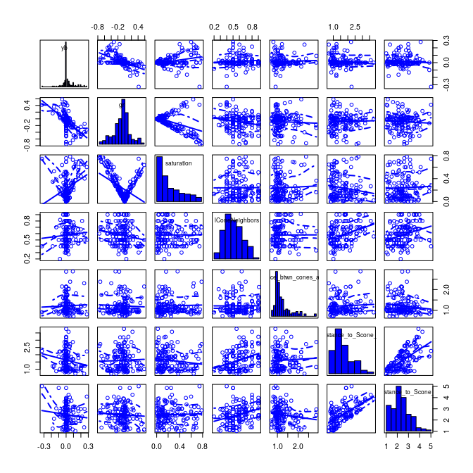

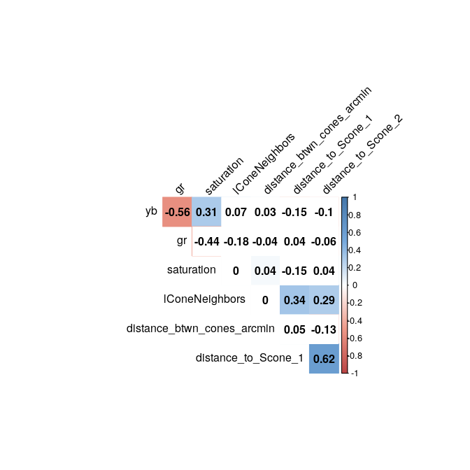

```r
predictors = c("yb", "gr", "saturation", "lConeNeighbors",
               "distance_btwn_cones_arcmin",  "distance_to_Scone_1",
               "distance_to_Scone_2")
corr_analysis(twoConesSummary, predictors)
```

## Two cone responses are an average of individual reports

While features of the mosaic and physical stimulus did not predict color reports, we hypothesized that the sensations recorded from individual cones would be predictive of paired stimulation conditions. To address this question, we matched the mean response from each cone pair with the the mean report from each cone tested individually.

```r
merged1 <- merge(twoConesSummary,
           select(singleConesSummary, subject,
                  session, masterID1, yb, gr, lConeNeighbors),
           by=c("subject", "session", "masterID1")) %>%
  rename(., yb12=yb.x, gr12=gr.x, yb1=yb.y, gr1=gr.y,
                  lConeNeighbors12=lConeNeighbors.x,
                  lConeNeighbors1=lConeNeighbors.y)
sessionMerge <- merged1 %>%
  merge(., select(singleConesSummary, subject, session,
                  masterID1, yb, gr, lConeNeighbors),
        by.x=c("subject", "session", "masterID2"),
        by.y=c("subject", "session", "masterID1")) %>%
  rename(., yb2=yb, gr2=gr, lConeNeighbors2=lConeNeighbors) %>%
  mutate(., saturation12=abs(yb12) + abs(gr12),
         saturation1=abs(yb1) + abs(gr1),
         saturation2=abs(yb2) + abs(gr2))
```

We then fit a linear model to the data. Behavioral reports from two cone stimulation were predicted by an average of the individual responses: $gr_{12} = (gr_1 + gr_2) / 2$. Below is a visualization of the measured responses against the predictions.

```r
sessionMerge['predictedYB'] = (sessionMerge$yb1 + sessionMerge$yb2) / 2
sessionMerge['predictedGR'] = (sessionMerge$gr1 + sessionMerge$gr2) / 2
sessionMerge['predictedSaturation'] = abs(sessionMerge$predictedYB) + abs(sessionMerge$predictedGR)
# Add a column w difference from prediction
sessionMerge <- mutate(sessionMerge,
                       diff_from_prediction=saturation12 - predictedSaturation)
```

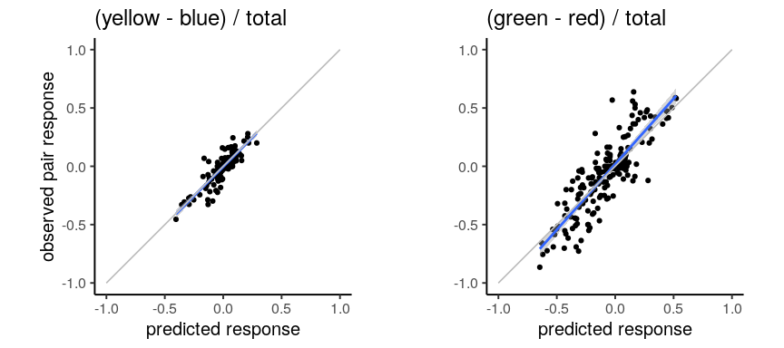

```r
unity = data.frame(x=c(-1, 1), y=c(-1, 1))
gr_plot <- sessionMerge %>%
  ggplot(., aes(x=predictedGR, y=gr12)) +
  geom_point() +
  geom_smooth(method=lm) +
  coord_equal(xlim=c(-1, 1), ylim=c(-1, 1)) +
  geom_path(data=unity, aes(x=x, y=y), colour='gray', linetype=1) +
  ggtitle('(green - red) / total') +
  geom_path(data=unity, aes(x=x, y=y), colour='gray', linetype=1) +
  xlab('predicted response') + ylab('') +
  theme_classic(base_size=15)
unity = data.frame(x=c(-1, 1), y=c(-1, 1))
yb_plot <- sessionMerge %>%
  ggplot(., aes(x=predictedYB, y=yb12)) +
  geom_point() +
  geom_smooth(method=lm) +
  coord_equal(xlim=c(-1, 1), ylim=c(-1, 1)) +
  geom_path(data=unity, aes(x=x, y=y), colour='gray', linetype=1) +
  ggtitle('(yellow - blue) / total') +
  geom_path(data=unity, aes(x=x, y=y), colour='gray', linetype=1) +
  xlab('predicted response') +
  ylab('observed pair response') +
  theme_classic(base_size=15)
p <- grid.arrange(yb_plot, gr_plot, nrow=1)
```

```r
ggsave("figures/prediction.pdf", p)
```

Results of linear regression (gr dimension followed by yb):

```r
# A linear model predicts the results based on an average of the individual responses.
mod <- lm(gr12 ~ predictedGR, sessionMerge)
summary.lm(mod)
```

```
Call:
lm(formula = gr12 ~ predictedGR, data = sessionMerge)

Residuals:
     Min       1Q   Median       3Q      Max
-0.45553 -0.09987 -0.00895  0.09816  0.57855

Coefficients:
            Estimate Std. Error t value Pr(>|t|)
(Intercept)  0.01772    0.01259   1.407    0.161
predictedGR  1.12390    0.05041  22.297   <2e-16 ***
---
Signif. codes:  0 ‘***’ 0.001 ‘**’ 0.01 ‘*’ 0.05 ‘.’ 0.1 ‘ ’ 1

Residual standard error: 0.1623 on 181 degrees of freedom
Multiple R-squared:  0.7331,    Adjusted R-squared:  0.7316
F-statistic: 497.2 on 1 and 181 DF,  p-value: < 2.2e-16
```

```r
mod <- lm(yb12 ~ predictedYB, sessionMerge)
summary.lm(mod)
```

```
Call:
lm(formula = yb12 ~ predictedYB, data = sessionMerge)

Residuals:
      Min        1Q    Median        3Q       Max
-0.203925 -0.017762  0.004318  0.018450  0.236417

Coefficients:
             Estimate Std. Error t value Pr(>|t|)
(Intercept) -0.004318   0.004214  -1.025    0.307
predictedYB  1.002010   0.043201  23.194   <2e-16 ***
---
Signif. codes:  0 ‘***’ 0.001 ‘**’ 0.01 ‘*’ 0.05 ‘.’ 0.1 ‘ ’ 1

Residual standard error: 0.05699 on 181 degrees of freedom
Multiple R-squared:  0.7482,    Adjusted R-squared:  0.7469
F-statistic:   538 on 1 and 181 DF,  p-value: < 2.2e-16
```

## Pairs with the same type are more saturated than predicted by average

A simple linear model captured a large fraction of the variance (>72%). However, there were some pairs that deviated substantially from the best fit line. We wondered whether the deviation from linearity might be predicted by the sub-class of the two cones. For instance, do an L- and M-cone interact in a non-linear manner, while two L or two M-cones sum linearly?

We found the saturation for each pair and subtracted it from the average of the two cones probed alone. Those results are plotted below. A unity line represents the condition where the observed saturation judgment was predicted exactly by the average of individual responses. Notice that the L+L and M+M pairs tend to fall above the unity line – particularly at higher saturation values. In contrast, the L+M pairs fall below the line. These observations indicate that the cones with the same spectral type produced slightly more saturated reports than predicted by the average of their individual responses.

```r
diffHist <- sessionMerge %>%
   filter(., typeID == 1 | typeID > 3) %>%
   ggplot(.,
          aes(x=saturation12 - predictedSaturation,
              color=as.factor(typeID))) +
  geom_freqpoly(binwidth=0.1, size=1.25) +
  scale_color_manual(
    values = c(gray, green, yellow, red),
    name="spectral type",
    labels = c("unknown-pair", "M+M", "L+M", "L+L")) +
  xlab("measured - predicted saturation") +
  theme_classic(base_size=15) +
  theme(legend.position=c(0.75, 0.80))
ggsave('figures/observed-predicted_histogram.pdf')
```

[figure not shown]

```r
t.test(sessionMerge %>%
         filter(., typeID == 5) %>%
         select(., diff_from_prediction)
       )
```

```
    One Sample t-test

data:  sessionMerge %>% filter(., typeID == 5) %>% select(., diff_from_prediction)
t = -1.9437, df = 56, p-value = 0.05696
alternative hypothesis: true mean is not equal to 0
95 percent confidence interval:
 -0.068670699  0.001035897
sample estimates:
 mean of x
-0.0338174
```

L+L and M+M pairs had a mean that was significantly different from zero, but in the opposite direction.

```r
t.test(sessionMerge %>%
         filter(., typeID == 4 | typeID == 6) %>%
         select(., diff_from_prediction)
       )
```

```
    One Sample t-test

data:  sessionMerge %>% filter(., typeID == 4 | typeID == 6) %>% select(.,     diff_from_prediction)
t = 4.172, df = 78, p-value = 7.772e-05
alternative hypothesis: true mean is not equal to 0
95 percent confidence interval:
 0.03748812 0.10592157
sample estimates:
 mean of x
0.07170484
```

Unclassified cones were significantly more saturated than predicted.

```r
t.test(sessionMerge %>%
         filter(., typeID == 1) %>%
         select(., diff_from_prediction)
       )
```

```
    One Sample t-test

data:  sessionMerge %>% filter(., typeID == 1) %>% select(., diff_from_prediction)
t = 4.0435, df = 46, p-value = 0.0001988
alternative hypothesis: true mean is not equal to 0
95 percent confidence interval:
 0.06116617 0.18243140
sample estimates:
mean of x
0.1217988
```

Finally, L+M pairs were significantly different from the population of responses collected from L+L and M+M pairs.

```r
t.test(sessionMerge %>%
         filter(., typeID == 5) %>%
         select(., diff_from_prediction),
       sessionMerge %>%
         filter(., typeID == 4 | typeID == 6) %>%
         select(., diff_from_prediction)
       )
```

[output not shown]

# Conclusions

Color sensations from pairs of cones were predicted by a simple average of individual responses. However, when two cones from the same subclass were probed, there was a systematic deviation from a simple average. These pairs produced significantly more saturated colors than predicted by an average of the colors elicited when probed alone. This observation suggests that the visual system uses a different strategy when combining information within versus across neuronal sub-classes.